# Wine Data Exploration by Terry Verner

The dataset contains nearly 5000 records of white wine flavor profiles and quality ratings.

# Univariate Plots Section

```
## [1] 4898   12
```

The dataset includes 4898 observations of 12 features.

```
## Classes 'tbl_df', 'tbl' and 'data.frame':    4898 obs. of  12 variables:
##  $ fixed.acidity       : num  7 6.3 8.1 7.2 7.2 8.1 6.2 7 6.3 8.1 ...
##  $ volatile.acidity    : num  0.27 0.3 0.28 0.23 0.23 0.28 0.32 0.27 0.3 0.22 ...
##  $ citric.acid         : num  0.36 0.34 0.4 0.32 0.32 0.4 0.16 0.36 0.34 0.43 ...
##  $ residual.sugar      : num  20.7 1.6 6.9 8.5 8.5 6.9 7 20.7 1.6 1.5 ...
##  $ chlorides           : num  0.045 0.049 0.05 0.058 0.058 0.05 0.045 0.045 0.049 0.044 ...
##  $ free.sulfur.dioxide : num  45 14 30 47 47 30 30 45 14 28 ...
##  $ total.sulfur.dioxide: num  170 132 97 186 186 97 136 170 132 129 ...
##  $ density             : num  1.001 0.994 0.995 0.996 0.996 ...
##  $ pH                  : num  3 3.3 3.26 3.19 3.19 3.26 3.18 3 3.3 3.22 ...
##  $ sulphates           : num  0.45 0.49 0.44 0.4 0.4 0.44 0.47 0.45 0.49 0.45 ...
##  $ alcohol             : num  8.8 9.5 10.1 9.9 9.9 10.1 9.6 8.8 9.5 11 ...
##  $ quality             : int  6 6 6 6 6 6 6 6 6 6 ...
```

The data types for the features are 11 numeric (float) and 1 integer.

```
##  fixed.acidity    volatile.acidity  citric.acid     residual.sugar
##  Min.   : 3.800   Min.   :0.0800   Min.   :0.0000   Min.   : 0.600
##  1st Qu.: 6.300   1st Qu.:0.2100   1st Qu.:0.2700   1st Qu.: 1.700
##  Median : 6.800   Median :0.2600   Median :0.3200   Median : 5.200
##  Mean   : 6.855   Mean   :0.2782   Mean   :0.3342   Mean   : 6.391
##  3rd Qu.: 7.300   3rd Qu.:0.3200   3rd Qu.:0.3900   3rd Qu.: 9.900
##  Max.   :14.200   Max.   :1.1000   Max.   :1.6600   Max.   :65.800
##    chlorides       free.sulfur.dioxide total.sulfur.dioxide
##  Min.   :0.00900   Min.   :  2.00      Min.   :  9.0
##  1st Qu.:0.03600   1st Qu.: 23.00      1st Qu.:108.0
##  Median :0.04300   Median : 34.00      Median :134.0
##  Mean   :0.04577   Mean   : 35.31      Mean   :138.4
##  3rd Qu.:0.05000   3rd Qu.: 46.00      3rd Qu.:167.0
##  Max.   :0.34600   Max.   :289.00      Max.   :440.0
##     density             pH          sulphates         alcohol
##  Min.   :0.9871   Min.   :2.720   Min.   :0.2200   Min.   : 8.00
##  1st Qu.:0.9917   1st Qu.:3.090   1st Qu.:0.4100   1st Qu.: 9.50
##  Median :0.9937   Median :3.180   Median :0.4700   Median :10.40
##  Mean   :0.9940   Mean   :3.188   Mean   :0.4898   Mean   :10.51
##  3rd Qu.:0.9961   3rd Qu.:3.280   3rd Qu.:0.5500   3rd Qu.:11.40
##  Max.   :1.0390   Max.   :3.820   Max.   :1.0800   Max.   :14.20
##     quality
##  Min.   :3.000
##  1st Qu.:5.000
##  Median :6.000
##  Mean   :5.878
##  3rd Qu.:6.000
##  Max.   :9.000
```

Let’s dive in to some univariate plotting to get a better look at a handful of these features and consider engineering new features. *All histograms contain the mean and median values depicted in orange and blue respectively.*

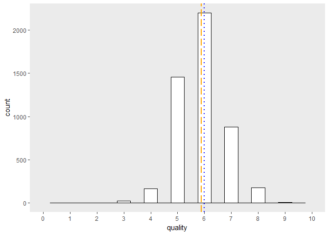

```
##
##    3    4    5    6    7    8    9
##   20  163 1457 2198  880  175    5
```

The distribution of quality is approximately normal. With a median of 6 and mean of 5.878, we can see the center of the data is slightly skewed toward the higher values. I would say the data exhibits a very slight left skew.

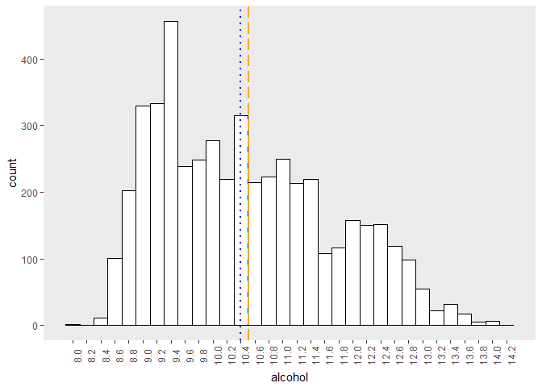

This is interesting because the data for alcohol is not normally distributed. The data is right skewed with the mean and median values at 10.51 and 10.4 respectively. However, the largest bin is 9.4 percent alcohol by volume.

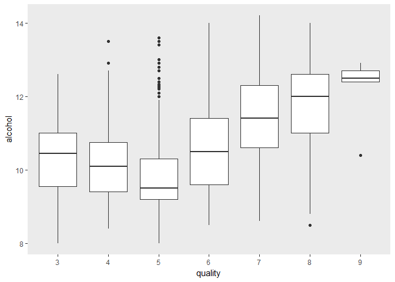

```
## white$quality: 3
##    Min. 1st Qu.  Median    Mean 3rd Qu.    Max.
##    8.00    9.55   10.45   10.35   11.00   12.60
## --------------------------------------------------------
## white$quality: 4
##    Min. 1st Qu.  Median    Mean 3rd Qu.    Max.
##    8.40    9.40   10.10   10.15   10.75   13.50
## --------------------------------------------------------
## white$quality: 5
##    Min. 1st Qu.  Median    Mean 3rd Qu.    Max.
##   8.000   9.200   9.500   9.809  10.300  13.600
## --------------------------------------------------------
## white$quality: 6
##    Min. 1st Qu.  Median    Mean 3rd Qu.    Max.
##    8.50    9.60   10.50   10.58   11.40   14.00
## --------------------------------------------------------
## white$quality: 7
##    Min. 1st Qu.  Median    Mean 3rd Qu.    Max.
##    8.60   10.60   11.40   11.37   12.30   14.20
## --------------------------------------------------------
## white$quality: 8
##    Min. 1st Qu.  Median    Mean 3rd Qu.    Max.
##    8.50   11.00   12.00   11.64   12.60   14.00
## --------------------------------------------------------
## white$quality: 9
##    Min. 1st Qu.  Median    Mean 3rd Qu.    Max.
##   10.40   12.40   12.50   12.18   12.70   12.90
```

It appears that in most, but not all cases, the alcohol content is more positively correlated with wine quality. The Pearson correlation coefficient is 0.4355747.

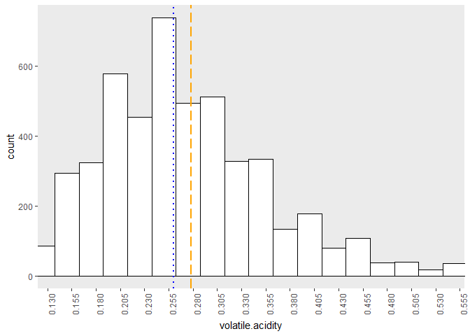

```
## white$quality: 3
##    Min. 1st Qu.  Median    Mean 3rd Qu.    Max.
##  0.1700  0.2375  0.2600  0.3332  0.4125  0.6400
## --------------------------------------------------------
## white$quality: 4
##    Min. 1st Qu.  Median    Mean 3rd Qu.    Max.
##  0.1100  0.2700  0.3200  0.3812  0.4600  1.1000
## --------------------------------------------------------
## white$quality: 5
##    Min. 1st Qu.  Median    Mean 3rd Qu.    Max.
##   0.100   0.240   0.280   0.302   0.340   0.905
## --------------------------------------------------------
## white$quality: 6
##    Min. 1st Qu.  Median    Mean 3rd Qu.    Max.
##  0.0800  0.2000  0.2500  0.2606  0.3000  0.9650
## --------------------------------------------------------
## white$quality: 7
##    Min. 1st Qu.  Median    Mean 3rd Qu.    Max.
##  0.0800  0.1900  0.2500  0.2628  0.3200  0.7600
## --------------------------------------------------------
## white$quality: 8
##    Min. 1st Qu.  Median    Mean 3rd Qu.    Max.
##  0.1200  0.2000  0.2600  0.2774  0.3300  0.6600
## --------------------------------------------------------
## white$quality: 9
##    Min. 1st Qu.  Median    Mean 3rd Qu.    Max.
##   0.240   0.260   0.270   0.298   0.360   0.360
```

The volatile acidity can, in high amounts, impart vinegar-like taste. The data for this feature is significantly right skewed.

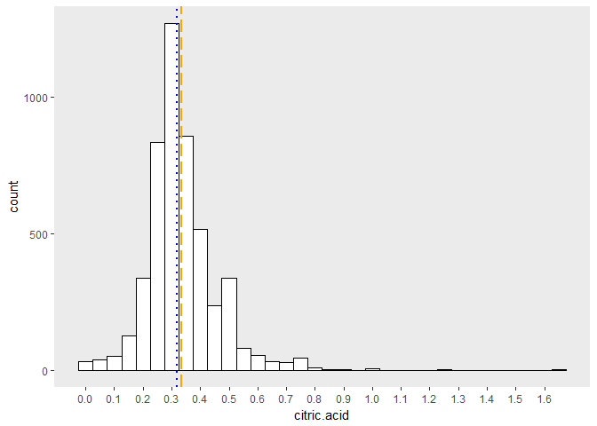

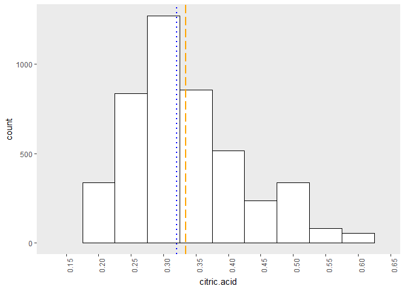

The data for this feature is right skewed; however, after zooming in to exclude outliers, the distribution is relatively normal. I might be able to combine this feature with another, or others, and glean some significant insights from it. Citric acid adds a freshness or light flavor to wine.

```
## white$quality: 3
##    Min. 1st Qu.  Median    Mean 3rd Qu.    Max.
##  0.2100  0.2575  0.3450  0.3360  0.3850  0.4700
## --------------------------------------------------------
## white$quality: 4
##    Min. 1st Qu.  Median    Mean 3rd Qu.    Max.
##  0.0000  0.1900  0.2900  0.3042  0.4000  0.8800
## --------------------------------------------------------
## white$quality: 5
##    Min. 1st Qu.  Median    Mean 3rd Qu.    Max.
##  0.0000  0.2400  0.3200  0.3377  0.4100  1.0000
## --------------------------------------------------------
## white$quality: 6
##    Min. 1st Qu.  Median    Mean 3rd Qu.    Max.
##   0.000   0.270   0.320   0.338   0.380   1.660
## --------------------------------------------------------
## white$quality: 7
##    Min. 1st Qu.  Median    Mean 3rd Qu.    Max.
##  0.0100  0.2800  0.3100  0.3256  0.3600  0.7400
## --------------------------------------------------------
## white$quality: 8
##    Min. 1st Qu.  Median    Mean 3rd Qu.    Max.
##  0.0400  0.2800  0.3200  0.3265  0.3600  0.7400
## --------------------------------------------------------
## white$quality: 9
##    Min. 1st Qu.  Median    Mean 3rd Qu.    Max.
##   0.290   0.340   0.360   0.386   0.450   0.490
```

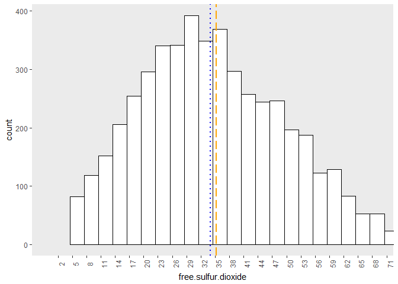

```
## white$quality: 3
##    Min. 1st Qu.  Median    Mean 3rd Qu.    Max.
##    5.00   13.25   33.50   53.33   47.50  289.00
## --------------------------------------------------------
## white$quality: 4
##    Min. 1st Qu.  Median    Mean 3rd Qu.    Max.
##    3.00    9.00   18.00   23.36   30.50  138.50
## --------------------------------------------------------
## white$quality: 5
##    Min. 1st Qu.  Median    Mean 3rd Qu.    Max.
##    2.00   22.00   35.00   36.43   50.00  131.00
## --------------------------------------------------------
## white$quality: 6
##    Min. 1st Qu.  Median    Mean 3rd Qu.    Max.
##    3.00   24.00   34.00   35.65   46.00  112.00
## --------------------------------------------------------
## white$quality: 7
##    Min. 1st Qu.  Median    Mean 3rd Qu.    Max.
##    5.00   25.00   33.00   34.13   41.00  108.00
## --------------------------------------------------------
## white$quality: 8
##    Min. 1st Qu.  Median    Mean 3rd Qu.    Max.
##    6.00   28.00   35.00   36.72   44.50  105.00
## --------------------------------------------------------
## white$quality: 9
##    Min. 1st Qu.  Median    Mean 3rd Qu.    Max.
##    24.0    27.0    28.0    33.4    31.0    57.0
```

After zooming in to exclude outliers, the distribution of free sulfur dioxide is normal. This is a feature I may be able to work with during later analysis.

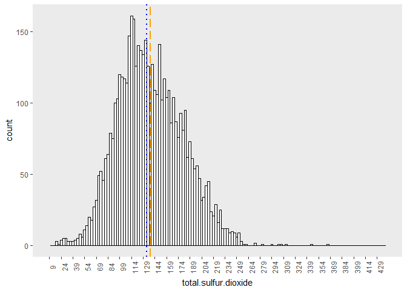

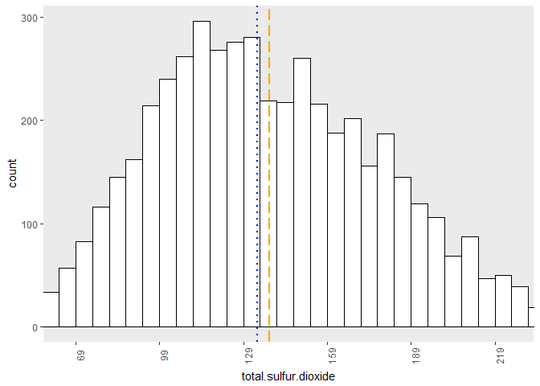

I like the look of this second histogram for total.sulfur.dioxide much better. After zooming to remove outliers, we can see the distribution presents a mostly normal appearance with some skew still extending to the right.

Let’s create two new features as the percentage of free sulfur dioxide and bound sulfur dioxide.

```r
white$so2.free.percent <- white$free.sulfur.dioxide / white$total.sulfur.dioxide
white$so2.bound.percent <- 1 - white$so2.free.percent
```

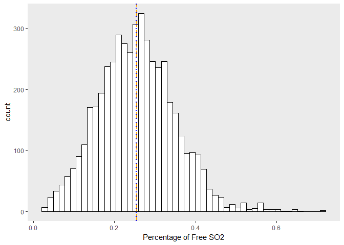

```
## white$quality: 3
##    Min. 1st Qu.  Median    Mean 3rd Qu.    Max.
## 0.04587 0.13952 0.19859 0.25736 0.29928 0.65682
## --------------------------------------------------------
## white$quality: 4
##    Min. 1st Qu.  Median    Mean 3rd Qu.    Max.
## 0.03371 0.10462 0.15730 0.18042 0.23539 0.58140
## --------------------------------------------------------
## white$quality: 5
##    Min. 1st Qu.  Median    Mean 3rd Qu.    Max.
## 0.02362 0.17188 0.23810 0.23772 0.29646 0.65000
## --------------------------------------------------------
## white$quality: 6
##    Min. 1st Qu.  Median    Mean 3rd Qu.    Max.
## 0.03361 0.19836 0.25862 0.26217 0.32046 0.71053
## --------------------------------------------------------
## white$quality: 7
##    Min. 1st Qu.  Median    Mean 3rd Qu.    Max.
##  0.0500  0.2118  0.2717  0.2757  0.3333  0.6429
## --------------------------------------------------------
## white$quality: 8
##    Min. 1st Qu.  Median    Mean 3rd Qu.    Max.
## 0.07895 0.22308 0.28829 0.28923 0.33635 0.60377
## --------------------------------------------------------
## white$quality: 9
##    Min. 1st Qu.  Median    Mean 3rd Qu.    Max.
##  0.1942  0.2258  0.2743  0.2911  0.2824  0.4790
```

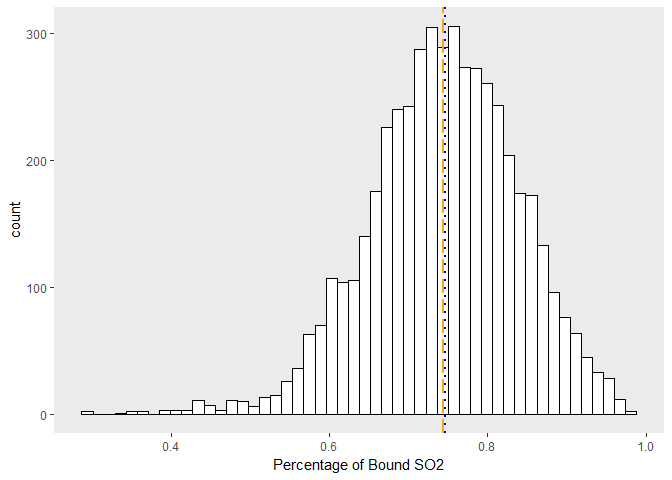

```
## white$quality: 3
##    Min. 1st Qu.  Median    Mean 3rd Qu.    Max.
##  0.3432  0.7007  0.8014  0.7426  0.8605  0.9541
## --------------------------------------------------------
## white$quality: 4
##    Min. 1st Qu.  Median    Mean 3rd Qu.    Max.
##  0.4186  0.7646  0.8427  0.8196  0.8954  0.9663
## --------------------------------------------------------
## white$quality: 5
##    Min. 1st Qu.  Median    Mean 3rd Qu.    Max.
##  0.3500  0.7035  0.7619  0.7623  0.8281  0.9764
## --------------------------------------------------------
## white$quality: 6
##    Min. 1st Qu.  Median    Mean 3rd Qu.    Max.
##  0.2895  0.6795  0.7414  0.7378  0.8016  0.9664
## --------------------------------------------------------
## white$quality: 7
##    Min. 1st Qu.  Median    Mean 3rd Qu.    Max.
##  0.3571  0.6667  0.7283  0.7243  0.7882  0.9500
## --------------------------------------------------------
## white$quality: 8
##    Min. 1st Qu.  Median    Mean 3rd Qu.    Max.
##  0.3962  0.6637  0.7117  0.7108  0.7769  0.9211
## --------------------------------------------------------
## white$quality: 9
##    Min. 1st Qu.  Median    Mean 3rd Qu.    Max.
##  0.5210  0.7176  0.7257  0.7089  0.7742  0.8058
```

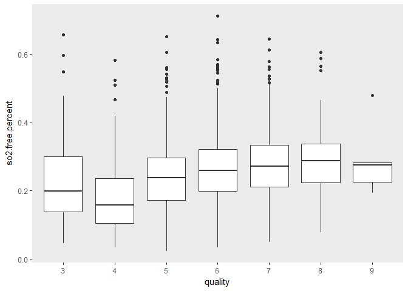

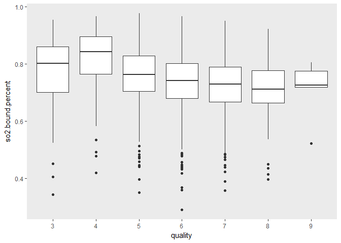

I think these percentage features can allow me greater insights into the quality of white wines. SO2 is required to prevent oxidation, however, a balance must be found to prevent a strong sulfuric smell in the nose or the taste.

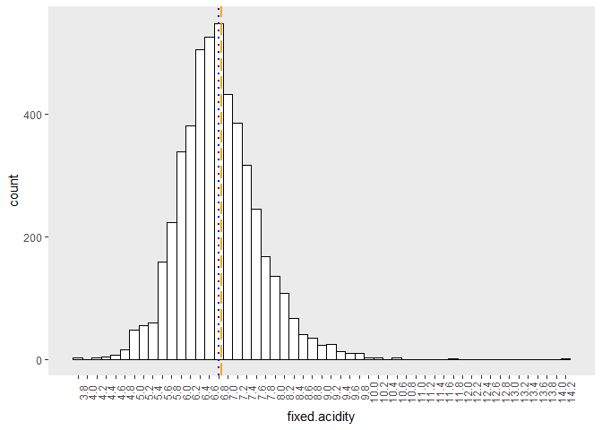

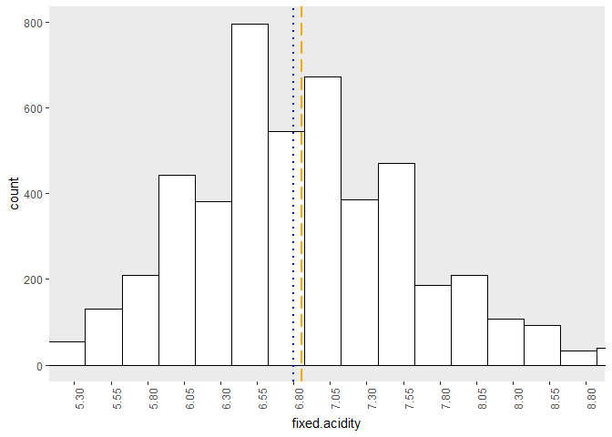

```
## white$quality: 3
##    Min. 1st Qu.  Median    Mean 3rd Qu.    Max.
##   4.200   6.575   7.300   7.600   8.525  11.800
## --------------------------------------------------------
## white$quality: 4
##    Min. 1st Qu.  Median    Mean 3rd Qu.    Max.
##   4.800   6.400   6.900   7.129   7.600  10.200
## --------------------------------------------------------
## white$quality: 5
##    Min. 1st Qu.  Median    Mean 3rd Qu.    Max.
##   4.500   6.400   6.800   6.934   7.400  10.300
## --------------------------------------------------------
## white$quality: 6
##    Min. 1st Qu.  Median    Mean 3rd Qu.    Max.
##   3.800   6.300   6.800   6.838   7.300  14.200
## --------------------------------------------------------
## white$quality: 7
##    Min. 1st Qu.  Median    Mean 3rd Qu.    Max.
##   4.200   6.200   6.700   6.735   7.200   9.200
## --------------------------------------------------------
## white$quality: 8
##    Min. 1st Qu.  Median    Mean 3rd Qu.    Max.
##   3.900   6.200   6.800   6.657   7.300   8.200
## --------------------------------------------------------
## white$quality: 9
##    Min. 1st Qu.  Median    Mean 3rd Qu.    Max.
##    6.60    6.90    7.10    7.42    7.40    9.10
```

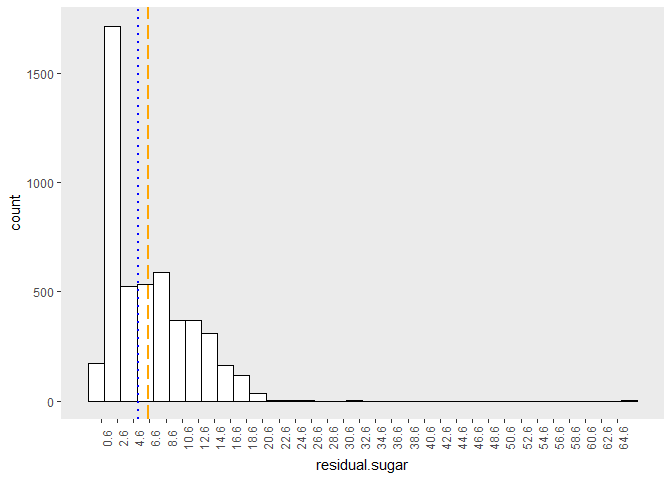

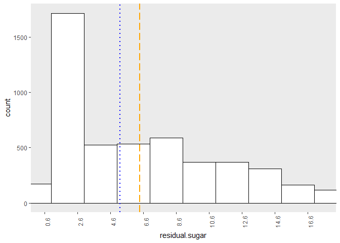

```
## white$quality: 3
##    Min. 1st Qu.  Median    Mean 3rd Qu.    Max.
##   0.700   1.587   4.600   6.393  10.700  16.200
## --------------------------------------------------------
## white$quality: 4
##    Min. 1st Qu.  Median    Mean 3rd Qu.    Max.
##   0.700   1.300   2.500   4.628   7.100  17.550
## --------------------------------------------------------
## white$quality: 5
##    Min. 1st Qu.  Median    Mean 3rd Qu.    Max.
##   0.600   1.800   7.000   7.335  11.500  23.500
## --------------------------------------------------------
## white$quality: 6
##    Min. 1st Qu.  Median    Mean 3rd Qu.    Max.
##   0.700   1.700   5.300   6.442   9.900  65.800
## --------------------------------------------------------
## white$quality: 7
##    Min. 1st Qu.  Median    Mean 3rd Qu.    Max.
##   0.900   1.700   3.650   5.186   7.325  19.250
## --------------------------------------------------------
## white$quality: 8
##    Min. 1st Qu.  Median    Mean 3rd Qu.    Max.
##   0.800   2.100   4.300   5.671   8.200  14.800
## --------------------------------------------------------
## white$quality: 9
##    Min. 1st Qu.  Median    Mean 3rd Qu.    Max.
##    1.60    2.00    2.20    4.12    4.20   10.60
```

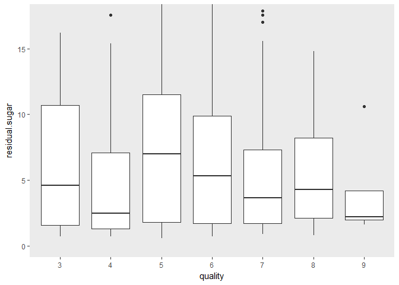

Residual.sugar is a nice feature because there may be a negative correlation with quality. I think I will need combine an additional feature, but I can gather something useful from residual.sugar.

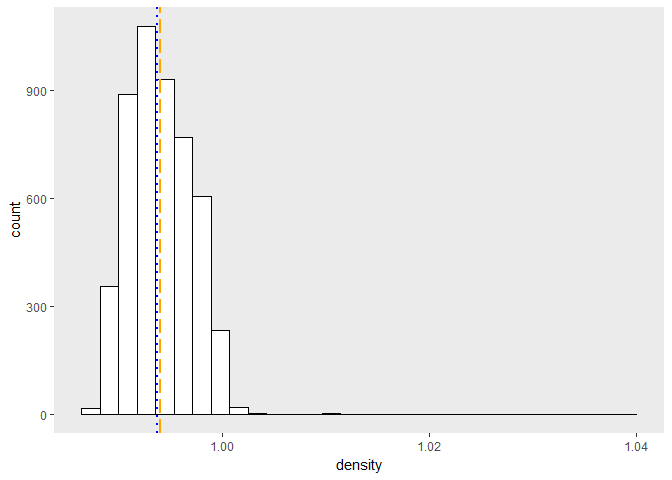

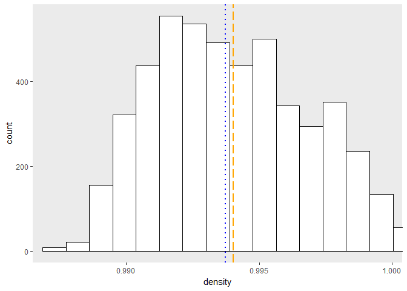

Excluding the outliers, the remaining distribution is relatively normal. Let’s view the data by quality to see what else we can draw out.

```
## white$quality: 3
##    Min. 1st Qu.  Median    Mean 3rd Qu.    Max.
##  0.9911  0.9925  0.9944  0.9949  0.9969  1.0001
## --------------------------------------------------------
## white$quality: 4
##    Min. 1st Qu.  Median    Mean 3rd Qu.    Max.
##  0.9892  0.9926  0.9941  0.9943  0.9958  1.0004
## --------------------------------------------------------
## white$quality: 5
##    Min. 1st Qu.  Median    Mean 3rd Qu.    Max.
##  0.9872  0.9933  0.9953  0.9953  0.9972  1.0024
## --------------------------------------------------------
## white$quality: 6
##    Min. 1st Qu.  Median    Mean 3rd Qu.    Max.
##  0.9876  0.9917  0.9937  0.9940  0.9959  1.0390
## --------------------------------------------------------
## white$quality: 7
##    Min. 1st Qu.  Median    Mean 3rd Qu.    Max.
##  0.9871  0.9906  0.9918  0.9925  0.9937  1.0004
## --------------------------------------------------------
## white$quality: 8
##    Min. 1st Qu.  Median    Mean 3rd Qu.    Max.
##  0.9871  0.9903  0.9916  0.9922  0.9935  1.0006
## --------------------------------------------------------
## white$quality: 9
##    Min. 1st Qu.  Median    Mean 3rd Qu.    Max.
##  0.9897  0.9898  0.9903  0.9915  0.9906  0.9970
```

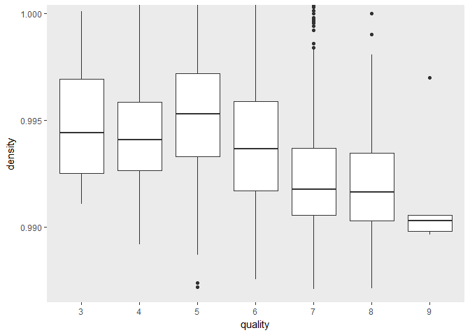

Interesting… While the differences between the measurements are so small, the data suggests there may be a correlation between density and quality. I think I will need to combine density with other features in the Bivariate section to explore the features impacting density. A combination of features could prove insightful.

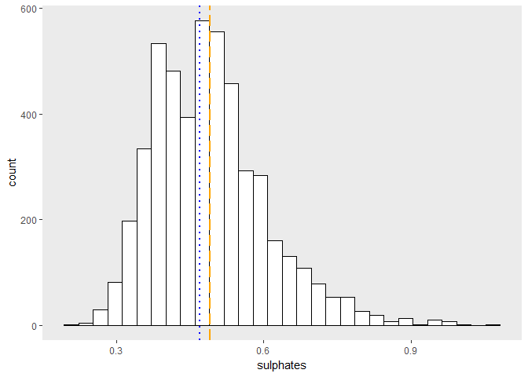

```
## white$quality: 3
##    Min. 1st Qu.  Median    Mean 3rd Qu.    Max.
##  0.2800  0.3800  0.4400  0.4745  0.5425  0.7400
## --------------------------------------------------------
## white$quality: 4
##    Min. 1st Qu.  Median    Mean 3rd Qu.    Max.
##  0.2500  0.3800  0.4700  0.4761  0.5400  0.8700
## --------------------------------------------------------
## white$quality: 5
##    Min. 1st Qu.  Median    Mean 3rd Qu.    Max.
##  0.2700  0.4200  0.4700  0.4822  0.5300  0.8800
## --------------------------------------------------------
## white$quality: 6
##    Min. 1st Qu.  Median    Mean 3rd Qu.    Max.
##  0.2300  0.4100  0.4800  0.4911  0.5500  1.0600
## --------------------------------------------------------
## white$quality: 7
##    Min. 1st Qu.  Median    Mean 3rd Qu.    Max.
##  0.2200  0.4100  0.4800  0.5031  0.5800  1.0800
## --------------------------------------------------------
## white$quality: 8
##    Min. 1st Qu.  Median    Mean 3rd Qu.    Max.
##  0.2500  0.3800  0.4600  0.4862  0.5850  0.9500
## --------------------------------------------------------
## white$quality: 9
##    Min. 1st Qu.  Median    Mean 3rd Qu.    Max.
##   0.360   0.420   0.460   0.466   0.480   0.610
```

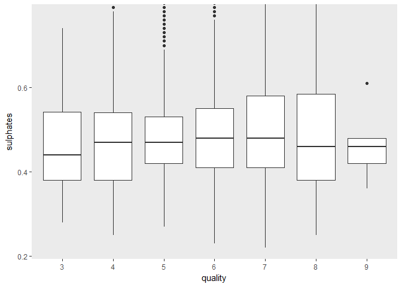

There doesn’t appear to be much correlation between sulphates and quality. I will need to explore sulphates with other features in the next section.

# Univariate Analysis

#### What is the structure of your dataset?

The data is now structured with 13 continuous features and 1 discrete, categorical output feature. With nearly 5000 observations, I may be able to glean more detailed insights or create more granular plots as compared to the red wines dataset of 1600 observations.

#### What is/are the main feature(s) of interest in your dataset?

The primary feature I am interested in is the output variable, quality. If the wine does not taste good, no one will drink it or even give much thought to its characteristics influencing that quality.

#### What other features in the dataset do you think will help support your investigation into your feature(s) of interest?

The other features I am interested in pertain to specific influences of taste. These are residual sugar and various measures of acidity.

#### Of the features you investigated, were there any unusual distributions? Did you perform any operations on the data to tidy, adjust, or change the form of the data? If so, why did you do this?

While I did not have to clean the data or make it tidy, I did observe unusual distributions of a handful of features. The unusual distribution could lead to some interesting insights, or perhaps lead me to a dead end.

# Bivariate Plots Section

```
##                      fixed.acidity volatile.acidity citric.acid
## fixed.acidity                1.000           -0.023       0.289
## volatile.acidity            -0.023            1.000      -0.149
## citric.acid                  0.289           -0.149       1.000
## residual.sugar               0.089            0.064       0.094
## chlorides                    0.023            0.071       0.114
## free.sulfur.dioxide         -0.049           -0.097       0.094
## total.sulfur.dioxide         0.091            0.089       0.121
## density                      0.265            0.027       0.150
## pH                          -0.426           -0.032      -0.164
## sulphates                   -0.017           -0.036       0.062
## alcohol                     -0.121            0.068      -0.076
## quality                     -0.114           -0.195      -0.009
## so2.free.percent            -0.139           -0.196       0.016
## so2.bound.percent            0.139            0.196      -0.016
##                      residual.sugar chlorides free.sulfur.dioxide
## fixed.acidity                 0.089     0.023              -0.049
## volatile.acidity              0.064     0.071              -0.097
## citric.acid                   0.094     0.114               0.094
## residual.sugar                1.000     0.089               0.299
## chlorides                     0.089     1.000               0.101
## free.sulfur.dioxide           0.299     0.101               1.000
## total.sulfur.dioxide          0.401     0.199               0.616
## density                       0.839     0.257               0.294
## pH                           -0.194    -0.090              -0.001
## sulphates                    -0.027     0.017               0.059
## alcohol                      -0.451    -0.360              -0.250
## quality                      -0.098    -0.210               0.008
## so2.free.percent              0.051    -0.033               0.739
## so2.bound.percent            -0.051     0.033              -0.739
##                      total.sulfur.dioxide density     pH sulphates alcohol
## fixed.acidity                       0.091   0.265 -0.426    -0.017  -0.121
## volatile.acidity                    0.089   0.027 -0.032    -0.036   0.068
## citric.acid                         0.121   0.150 -0.164     0.062  -0.076
## residual.sugar                      0.401   0.839 -0.194    -0.027  -0.451
## chlorides                           0.199   0.257 -0.090     0.017  -0.360
## free.sulfur.dioxide                 0.616   0.294 -0.001     0.059  -0.250
## total.sulfur.dioxide                1.000   0.530  0.002     0.135  -0.449
## density                             0.530   1.000 -0.094     0.074  -0.780
## pH                                  0.002  -0.094  1.000     0.156   0.121
## sulphates                           0.135   0.074  0.156     1.000  -0.017
## alcohol                            -0.449  -0.780  0.121    -0.017   1.000
## quality                            -0.175  -0.307  0.099     0.054   0.436
## so2.free.percent                   -0.013  -0.066  0.001    -0.022   0.064
## so2.bound.percent                   0.013   0.066 -0.001     0.022  -0.064
##                      quality so2.free.percent so2.bound.percent
## fixed.acidity         -0.114           -0.139             0.139
## volatile.acidity      -0.195           -0.196             0.196
## citric.acid           -0.009            0.016            -0.016
## residual.sugar        -0.098            0.051            -0.051
## chlorides             -0.210           -0.033             0.033
## free.sulfur.dioxide    0.008            0.739            -0.739
## total.sulfur.dioxide  -0.175           -0.013             0.013
## density               -0.307           -0.066             0.066
## pH                     0.099            0.001            -0.001
## sulphates              0.054           -0.022             0.022
## alcohol                0.436            0.064            -0.064
## quality                1.000            0.197            -0.197
## so2.free.percent       0.197            1.000            -1.000
## so2.bound.percent     -0.197           -1.000             1.000
```

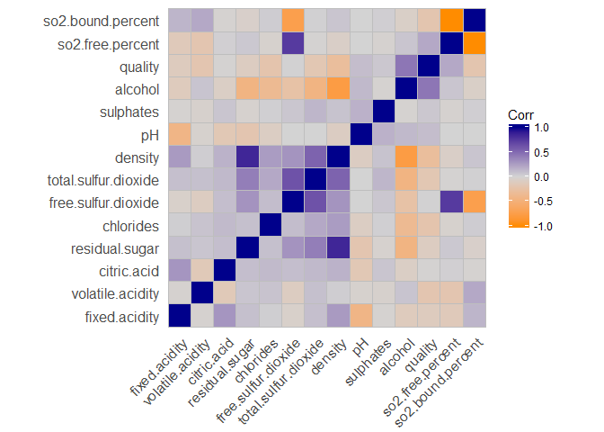

This correlation plot is not encouraging in determining very many strong relationships, at least at a rudimentary level. I will likely need to slice and manipulate my plots further to glean actionable insights. The multivariate plots should help drill down better in the section following.

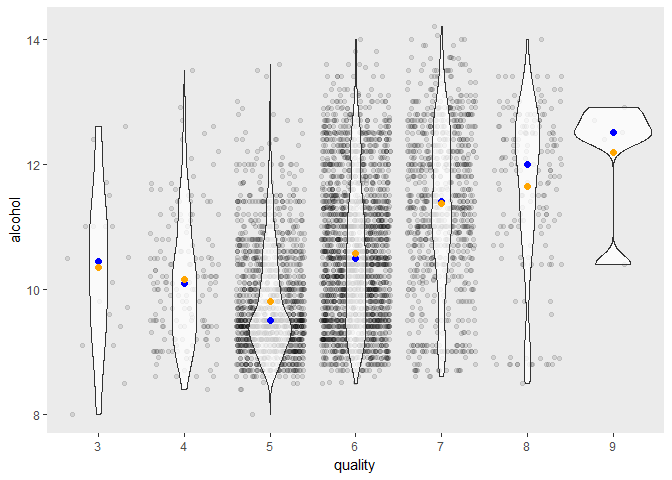

Although faint, there may a positive correlation between quality and alcohol content. The correlation coefficient of these two features is 0.4355747. One satisfying aspect of this particular visualization is the shape of the violin for the highest quality wines: it distinctly resembles a wine glass.

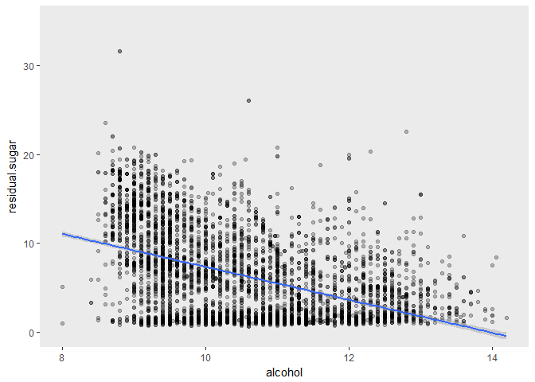

This plot suggests a weak to moderate negative correlation between alcohol and residual sugar. Higher residual sugar levels more frequently correspond to lower alcohol levels. This surprises me to certain degree because other types of strong alcohols try to make their beverage more palatable and to mask the strength of the alcohol. This, however, suggests many of the strong wines have lower levels of residual sugar.

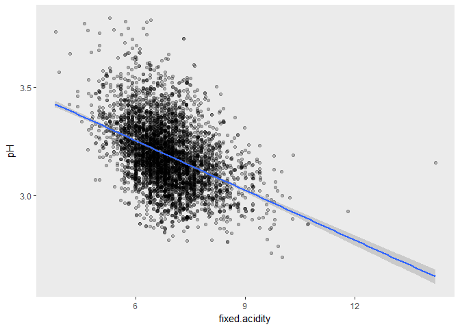

pH and fixed.acidity shows a moderate negative correlation as I expected. This is due to acids being represented by lower values on the pH scale.

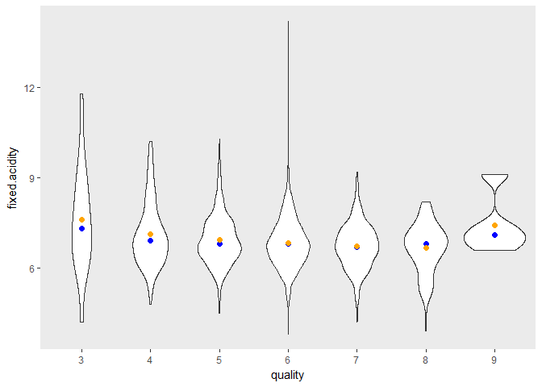

I was hopeful the fixed acidity level might be well described by quality; however, the correlation appears to be weakly negative to not correlated.

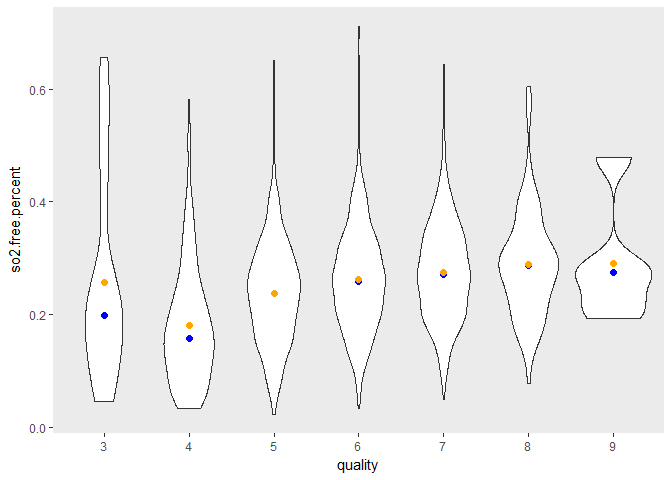

The percentage of free sulfur dioxide compared to the total, did not end up as descriptive as I anticipated it could be, nor predictive in terms of one being described by the other.

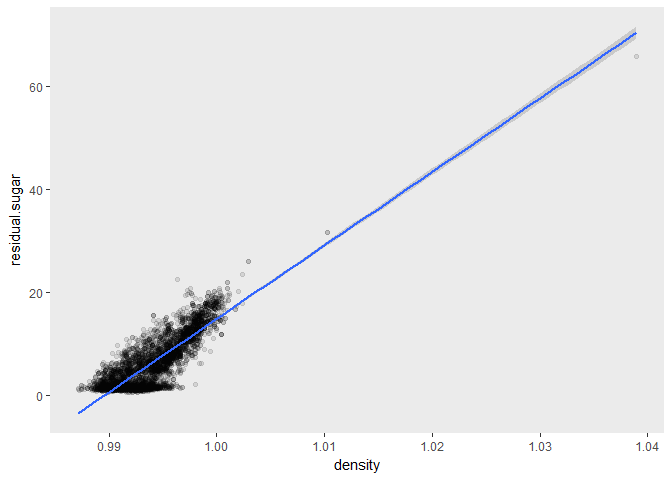

Even without zooming in to confirm at a smaller scale, I can see a strongly positive correlation between density and residual sugars. This is expected because sugar is typically heavier and more dense than the other chemicals composing a beverage or other liquid solution.

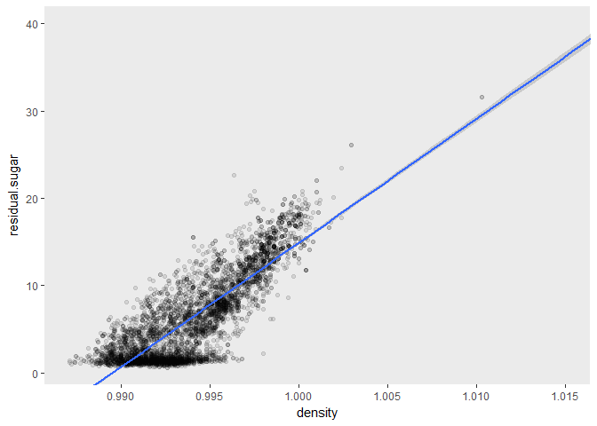

Zoomed in, the previous plot trendline is more easily observed. There is a correlation between density and residual.sugar

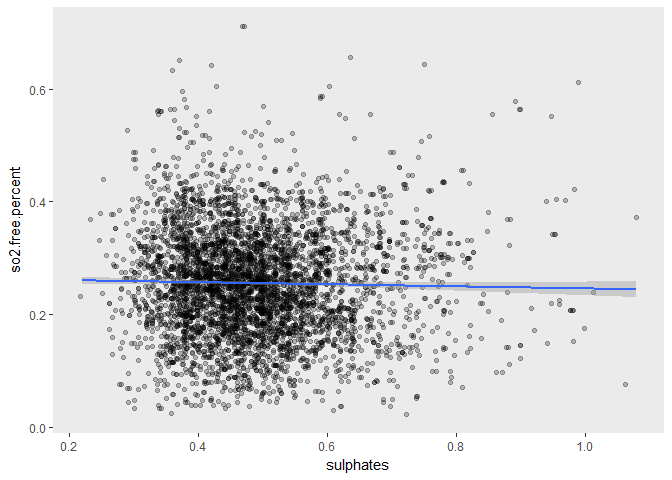

I was genuinely surprised there is effectively no correlation between sulphates and so2.percent. I would expect one feature to influence the other, yet this plot suggests that is not the case.